# τ=1.0 물리 seed로 되살린 해상도 zero-shot

PEMFC Bruggeman 클로저 역복원 — 분기 선택(branch selection) 문제로서의 재해석

## 요약

**한 문장**: 앞선 zero-shot들이 실패한 원인은 모델 결함이 아니라 **순전파가 두 해(calm/flooding) 중 틀린 가지를 골랐기 때문**이며, τ=1.0 물리 seed 하나로 올바른 가지를 선택시키자 세 메쉬 모두에서 GT 없이 flooding이 재현됐다.

- **1부** 앞선 zero-shot이 왜 제대로 실행되지 않았나 — 이론적 배경 (fold·다중해·seed 의존 + τ·g 근본 원인)
- **2부** 이번 zero-shot에서 수행한 검증 — 0단계 → 방법 A
- **3부** 검증 결과 — 해상도 zero-shot 성립
- **4부** 왜 이 방식이 성공했나 — basin of attraction

# 1부 · 이론적 배경

이론적 배경 — 앞선 zero-shot은 왜 제대로 실행되지 않았나

## 1-1. 문제 구조 — g의 이중 역할과 flooding 되먹임

역추정 대상은 유효확산 보정 $g(\phi_g)=\phi_g^{\tau}$ (합성 진실값 $\tau=1.1$).

- $g$는 **O₂ 확산과 H₂O 배출에 동시에** 걸린다 → 단순 단조 관계가 아님
- 고-$\eta$에서 **flooding 되먹임**: 물 축적 → $\phi_g=\varepsilon_p(1-s)\!\downarrow$ → $g\!\downarrow$ → 산소공급·전류 변화 → 되먹임
- 임계 전류를 넘으면 **saddle-node fold** ($\eta\approx0.385$)에서 flooding 해가 새로 태어난다

**핵심 — 고-$\eta$에서 해가 둘 공존**

같은 $\eta$·같은 방정식·같은 $g$에 대해 **calm 해($s\approx0.01$)** 와 **flooding 해($s\approx0.34$)** 가 동시에 존재한다.

## 1-2. 음함수 정리의 “국소성” → 두 사상

$F(w;\theta)=0$, $\partial F/\partial w$ 정칙이면 $w=w(\theta)$가 **국소적으로** 유일($C^1$).

- 그러나 fold 근처에서 $\partial F/\partial w$가 **특이**해진다
- 여러 해 가지(branch)가 공존 → **어느 가지 위의 해인지는 초기 추측이 정한다**

**두 개의 서로 다른 순전파 사상**

$$w_{\text{anchored}}(\theta)\;\ne\;w_{\text{self}}(\theta)\quad\Rightarrow\quad J_{\text{anchored}}(\theta)\;\ne\;J_{\text{self}}(\theta)$$
학습은 $J_{\text{anchored}}$를 최소화했다. 그러나 우리가 원한 것은 $J_{\text{self}}$였다.

## 1-3. 앞선 zero-shot의 정체 — 재해석

| 결과 | 원래 해석 | 재해석 |
| --- | --- | --- |
| train loss $10^{-5}$ | 잘 수렴 | GT 궤도 위에서 잰 값 |
| closure 1.8% | $g$ 복원 성공 | 자력으로는 **−38%** |
| 메쉬 zero-shot 1.5~2% | 이산화 독립 일반화 | **GT 궤도가 거의 같아 통과** |
| Lx zero-shot 발산 | Lx 변화가 커서 | **자력 능력 부재의 당연한 귀결** |

**노트**

GT-앵커 continuation은 **궤도 전체 출발선을 GT 위에** 놓는다 → 38% 틀린 $g$로도 GT 궤도를 따라간다. cold-start는 반대로 calm에 갇혀 **−38%**. 즉 “일반화”가 아니라 **GT 궤도 유사도**를 측정한 것.

## 1-4. 근본 원인 — τ·g 범위와 참값 위치

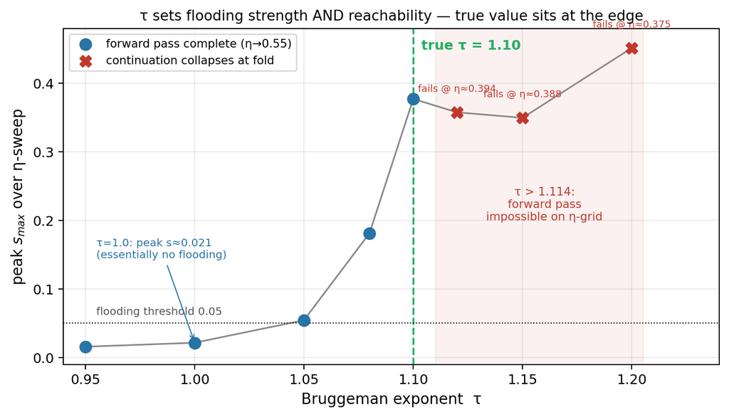

**참값 $\tau=1.1$이 순전파 가능 경계에 인접**

- peak $s_{\max}$가 $\tau$에 극도로 비선형: $1.0\!\to\!0.021$, $1.05\!\to\!0.054$, $1.1\!\to\!0.377$
- $\tau\!\gtrsim\!1.114$부터 현재 $\eta$격자에서 **fold 붕괴** (margin $\approx0.014$)

**세 가지 강제 결과**

1. 정보(flooding)와 도달성이 **같은 축에서 상충**
2. $g$의 2% 오차가 **−38%로 비선형 증폭**
3. calm/flooding **basin 경계가 극도로 가파름** → seed가 지배

## 1-5. 선결 조건 — 자력 순전파

**zero-shot의 전제**

새 도메인에는 정의상 **GT가 없다**. 따라서 **자력 순전파(self-driven) 능력**이 선결 조건이다. 학습 도메인에서조차 38% 틀리는 모델로는 zero-shot 주장이 성립하지 않는다.

- 그런데 자력 순전파는 flooding에 **도달하지 못한다** ($s_{\max}=0.0102$ 붙박이)
- ⟹ 진짜 병목은 “측정”이 아니라 **도달성(reachability)**

# 2부 · 수행한 검증

0단계(운전조건 축 기각) → 방법 A(물리 seed)

## 2-1. 0단계 — 운전조건 축을 먼저 배제

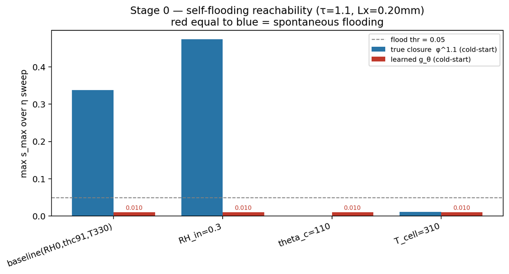

**질문**: flooding 가지가 충분히 강해져 $g_\theta$의 cold-start까지 끌어들이는 운전조건이 있는가?

**결과** (τ=1.1 고정, cold-start)

- 참 closure(파랑)는 baseline에서도 flooding
- **$g_\theta$(빨강)는 RH·θc·T 어떤 조건에서도 $s_{\max}=0.0102$ 붙박이**
- RH=0.3은 flooding을 40% 키웠는데도 $g_\theta$ 불변

⟹ 병목은 **운전조건이 아니다**. 탐색공간 절반을 잘라냄.

## 2-2. 방법 A — 각 η에서 물리 seed로 warm-start

각 $\eta$에서 물리 seed로 warm-start한 뒤 $g_\theta$ Newton을 수렴시켜, $g_\theta$가 그 $\eta$에서 flooding 해를 **갖는지 / 도달하는지**를 분리 진단.

- **A1** seed=τ1.0 → $g_\theta$ : 방법 A의 문자 그대로(배치에 정당)
- **A2** seed=τ1.1 GT → $g_\theta$ : $g_\theta$의 flooding 가지가 **존재하는지** (진단용)
- **C** seed=τ1.0 → 참 τ1.1 : 양성 대조(seed 강도 검증)

**노트**

τ=1.0은 **사전 커밋한 교과서 상수**(정답 1.1 아님). seed는 정확도가 아니라 **가지 선택**만 담당 → 누출 없음.

## 2-3. 방법 A 판정 — 존재 + 도달성

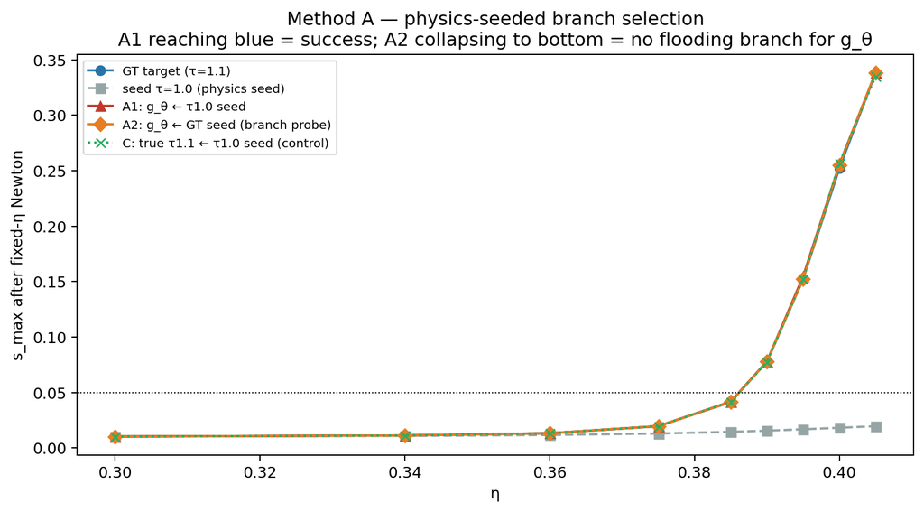

**A2(존재)**: GT flooding 상태에서 $g_\theta$가 0~1회 반복으로 **머문다** → flooding 자기완결 해가 **실재**

**A1(도달성)**: 약한 τ1.0 seed(s≈0.02)로 warm-start한 $g_\theta$가 **6회 만에 s=0.34**로 올라앉아 GT와 ~1% 일치

**C(대조)**: 참 closure도 회복, 다만 고-η에서 19·24회로 더 힘겹게 수렴

⟹ **가지도 있고, 정당한 seed로 도달 가능**

# 3부 · 검증 결과

해상도 zero-shot 성립

## 3-1. τ=1.0-seed 자력 순전파를 세 메쉬에 이식

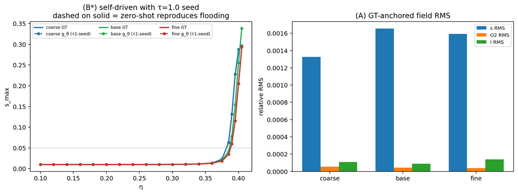

각 메쉬에서 τ=1.0 scalar 궤적을 per-η seed로 사용 → $g_\theta$ `solve_at_eta`

**GT를 전혀 쓰지 않는** 정당한 zero-shot 순전파.

왼쪽: $s_{\max}$ 궤적 — 점선($g_\theta$)이 실선(GT)에 **겹침**

오른쪽: (A) GT-앵커 field RMS — 세 메쉬에서 평탄

## 3-2. 결과 표 — −38% → ~0.001%

| 메쉬 | GT $s_{\max}$ | $g_\theta$ $s_{\max}$ | $s_{\max}$ 오차 | **I 오차(top-η)** | flooding? |
| --- | --- | --- | --- | --- | --- |
| coarse (16×40) | 0.2952 | 0.2965 | +0.4% | **0.0051%** | ✅ |
| base (24×60) | 0.3379 | 0.3383 | +0.1% | **0.00096%** | ✅ |
| fine (32×80) | 0.2900 | 0.2941 | +1.4% | **0.0092%** | ✅ |

# 4부 · 왜 성공했나

basin of attraction

## 4-1. basin of attraction — 개념

**끌림 영역(basin of attraction)** = 같은 반복(Newton)을 서로 다른 시작점에서 출발시켰을 때 **같은 해로 수렴하는 시작점들의 집합**.

- 지형 비유: 빗방울이 어느 골짜기로 모이느냐는 **어느 사면에 떨어졌느냐**(능선=분수령)
- 해가 여럿일 때, 도착지는 **초기 상태의 basin 소속**이 정한다 (= “seed가 가지를 선택한다”)
- basin은 **초기 상태 공간(w)** 위에서 정의됨 — θ는 basin의 모양(경계 가파름)을 바꾼다

## 4-2. 왜 τ=1.0 seed로 되는가

**핵심**: basin 소속은 **진폭($s_{\max}$)이 아니라 위치(구조)** 로 결정된다.

- τ=1.0 궤적 자체는 flooding 안 함(peak $s_{\max}\approx0.021$)
- 그러나 τ=1.0→1.1은 **연속 변형** → 가지의 위상 구조가 이어짐
- τ=1.0의 (약한) flooding 가지 점은 물이 막에 쌓이는 **flooding 구조**를 이미 가짐 → $g_\theta$의 강한 flooding **basin 안**에 든다
- Newton이 6회로 $s$ 0.02→0.34 **능동 이동**(진폭 17배 도약 = seed 잔차 다듬기가 아님)

## 4-3. 근본 원인과의 연결

**왜 seed가 이토록 결정적인가**

참값이 **fold 붕괴 경계에 인접** = 두 basin의 경계(분수령)가 **칼날처럼 가파름**.

- 참 closure의 continuation은 flooding 쪽으로 꺾이지만, **2% 다른 $g_\theta$의 continuation은 반대편(calm)으로 미끄러진다** — 이것이 −38%의 정체
- 경계가 가파를수록 seed가 지배적 → **올바른 basin에 드는 정당 seed 하나**(τ=1.0)로 문제가 풀린다

## 결론

**한계 · 향후**

- 자력 **학습**에의 이식(GT 첫점 seed → τ=1.0 seed)은 미검증 (fine-tune 안전, from-scratch 확인 대상)
- fine 메쉬 $s_{\max}$가 낮은 것은 방법이 아니라 **GT 자체의 수렴 거동**(정점 해상도)